# word embedding

Mao Wang

2021/1/4

```r
library(tidyverse)
library(tidytext)
library(quanteda) # install.packages("quanteda")
library(jiebaR)

library(wordVectors) # devtools::install_github("bmschmidt/wordVectors")
library(irlba) # install.packages("irlba") # for svd

## 降維
library(Rtsne) # install.packages("Rtsne")
```

## 1. 詞嵌入（word embedding）

“You shall know a word by the company it keeps.” (John R. Firth, 1957)

詞嵌入的基本概念很簡單，也不是近期才有的概念，但因為需要**大量的語料與運算資源**，直到2013年才由google工程師 [Tomas Mikolov等人](https://arxiv.org/pdf/1301.3781.pdf)提出操作方式，並實際應用在文字探勘上，取得了非常好的效果，也加速了近年來自然語言處理的發展。簡單來說，詞嵌入的做法讓程式語言更理解人類語言中的**相似詞**，而不需要太多的標記資料（如結構樹資料庫treebank）。

## 2. 英文資料

在做詞嵌入前，**基本的資料清理程序還是必須要做的事**，轉換小寫、移除停用詞、數字、標點符號等都不可或缺。

```r
# 用data frame的格式
# 讀入資料，並做文字資料清理
trump <- readr::read_lines("data/trumpspeeches.txt") %>%
  tibble(text = .) %>%
  mutate(id = dplyr::row_number()) %>%
  # 不在data frame的格式下移除停用字（現在是在character vector的情況下移除停用字）
  # 改為小寫
  mutate(text = str_to_lower(text)) %>%
  # 移除停用字
  mutate(text = tm::removeWords(text,
                                tidytext::stop_words$word)) %>%
  # 移除數字
  mutate(text = str_replace_all(text, pattern = "\\d+",
                                replacement = ""),
         # 移除標點符號
         text = str_replace_all(text, pattern = "[:punct:]",
                                replacement = " "),
         # 移除donald與trump
         text = str_remove_all(text, pattern = "donald|trump"),
         # 移除多餘的空白
         text = str_squish(text)) %>%
  # 欄位重新排序
  select(id, text)

trump
```

```
## # A tibble: 56 × 2
##       id text
##    <int> <chr>
##  1     1 "wow whoa people thousands nice nice tower wonderful city york honor e…
##  2     2 "evening speak lifelong supporter true friend israel newcomer politics…
##  3     3 "opportunity speak center national honoring invitation talk develop fo…
##  4     4 "joining speech hillary clinton bad president times radical islamic te…
##  5     5 "share stakes election people running president built amazing business…
##  6     6 "chairman jeff miller leadership behalf served country military unifor…
##  7     7 "honor honor wonderful day aww chants wow saturday morning nice incred…
##  8     8 "friends delegates fellow americans humbly gratefully accept nominatio…
##  9     9 "days crooked hillary clinton press conference reporters glowing repor…
## 10    10 "afternoon begin conversation america safe twentieth century united de…
## # … with 46 more rows
```

```r
# 用corpus的格式（quanteda的前處理方式）
trump_vec <- readr::read_lines("data/trumpspeeches.txt")
trump_corpus <- corpus(x = trump_vec) %>%
  quanteda::tokens(what = "word",
                   remove_numbers = TRUE,
                   remove_punct = TRUE,
                   # padding = TRUE
                   ) %>%
  tokens_tolower() %>%
  tokens_remove(pattern = c(tidytext::stop_words$word, "donald", "trump"))
```

我們之前大多是使用`tidytext`來轉換成`tm`套件裡的document-term matrix（dtm）格式來儲存文字資料，但其實還有另一種矩陣格式也常用來儲存文字資料，尤其是當我們在做詞嵌入時，必須計算每一字詞脈絡前後出現的字詞與數量，這種格式就叫做詞共現矩陣（term co-occurence matrix, tcm），我們使用之前沒介紹過的`quanteda`裡面的`fcm`函式來來達成這項工作。以下是函式的範例。

```r
# 這裡不是真的要跑code，只是展示fcm裡可以調控的參數。
quanteda::fcm(x,
    context = c("document", "window"),
    count = c("frequency", "boolean", "weighted"),
    window = 5L, ordered = FALSE, weights = 1L, tri = TRUE, ...)
```

在理解「詞共現矩陣」（feature co-occurence matrix, fcm）的基本結構後，將依照我們的需求，做出搜尋每個字前後脈絡詞並計算出現的次數（或有無出現、權重等不同表示）。完成後，再使用奇異值分解的方式降低維度。

```r
# 實際做出詞共現矩陣
trump_fcm <- quanteda::fcm(
  # x可以是    tokens or dfm object
  x = quanteda::corpus(trump) %>% tokens(),
  context = "window",
  count = "frequency",
  window = 5L,
  ordered = TRUE)

# 中途岔開一下，如果只用fcm的資料，其實也可以做出有點意義的東西
feat <- names(quanteda::topfeatures(trump_fcm, 50))

# 只留下前50常出現的詞彙
trump_fcmat_top <- fcm_keep(trump_fcm, pattern = feat)

dim(trump_fcmat_top)
```

```
## [1] 50 50
```

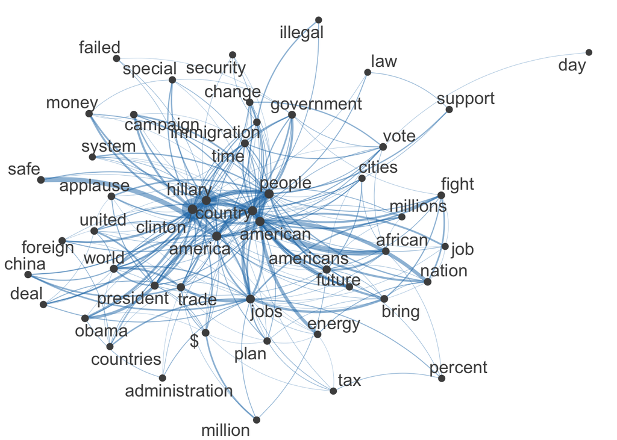

```r
size <- log(colSums(trump_fcmat_top))

# install.packages("quanteda.textplots")
# 接著要把共現網絡的詞彙畫出來
library(quanteda.textplots)
set.seed(144)
co_word_plot <- textplot_network(trump_fcmat_top, min_freq = 0.8,
                                 vertex_size = size / max(size) * 3)

co_word_plot
```

```r
# 轉換成矩陣格式
trump_mat <- as.matrix(trump_fcm)

# 奇異值分解（singular value decomposition, SVD）
# 降維
tictoc::tic()
trump_svd <- irlba(trump_mat,
                   # 要轉換成多少維度的向量空間（欄位）
                   nv = 200, maxit = 1e3)
tictoc::toc()
```

```
## 65.19 sec elapsed
```

```r
beepr::beep(2)
# ?irlba

# 看看trump_svd裡面有哪些資訊
names(trump_svd)
```

```
## [1] "d"     "u"     "v"     "iter"  "mprod"
```

```r
# d 代表奇異值（singular value），v 代表奇異值向量。我們需要的是重組過後的奇異值向量。

# 檢視矩陣的維度（列、欄數）
dim(trump_svd$u)
```

```
## [1] 6194  200
```

```r
# 因為svd矩陣是沒有rownames，把原本的rownames加回去，方便之後計算相似度的語法
rownames(trump_svd$u) <- rownames(trump_mat)

# 轉換為wordVectors的object，就可以直接用比較簡要的function來算相似性
# ?wordVectors::as.VectorSpaceModel
trump_w2v <- wordVectors::as.VectorSpaceModel(trump_svd$u)
```

前置作業都完成了，我們用自己的文本訓練出了自己的詞向量，接下來可以使用你感興趣的詞彙，來找出詞義最相近的詞。

```r
# 找語義（semantics）最接近的詞
trump_w2v %>% wordVectors::closest_to(vector = "tariff", n = 15)
```

```
##          word similarity to "tariff"
## 1      tariff              1.0000000
## 2      trucks              0.8446581
## 3        junk              0.8436575
## 4   broadcast              0.7751358
## 5   jerusalem              0.7520034
## 6        seas              0.7325031
## 7   equipment              0.5791129
## 8      patrol              0.5634758
## 9        mail              0.5099822
## 10 exploiting              0.4913793
## 11     hacked              0.4898276
## 12 manycancel              0.4891474
## 13      steel              0.4782887
## 14     saudis              0.4682265
## 15   schlafly              0.4665116
```

```r
# 如同向量一樣，也可以做加減
trump_w2v %>% wordVectors::closest_to(~ "tariff" - "mexico", n = 15)
```

```
##           word similarity to "tariff" - "mexico"
## 1       upside                         0.2245065
## 2      hampton                         0.2025685
## 3   portsmouth                         0.1712214
## 4  flourishing                         0.1653066
## 5   squandered                         0.1551569
## 6       travel                         0.1546068
## 7   excellence                         0.1516976
## 8    enactment                         0.1457847
## 9         envy                         0.1455426
## 10     hunters                         0.1436392
## 11       laugh                         0.1391938
## 12       strip                         0.1382921
## 13         due                         0.1360441
## 14      spaces                         0.1336009
## 15 competitors                         0.1305662
```

```r
trump_w2v %>% wordVectors::closest_to(~ "tariff" + "mexico", n = 15)
```

```
##          word similarity to "tariff" + "mexico"
## 1      mexico                         0.9994934
## 2       drink                         0.7205763
## 3       flint                         0.6749031
## 4       water                         0.6635468
## 5   collapsed                         0.5912913
## 6         car                         0.5228450
## 7  production                         0.4766280
## 8    drinking                         0.4103307
## 9      moving                         0.4026400
## 10       cars                         0.3852688
## 11      upset                         0.3708582
## 12   chrysler                         0.3522821
## 13    flowing                         0.3350267
## 14 everglades                         0.3348374
## 15     closed                         0.3246582
```

```r
trump_w2v %>% wordVectors::closest_to(~ "tariff" - "china", n = 15)
```

```
##                word similarity to "tariff" - "china"
## 1        terminated                        0.2349276
## 2     renegotiating                        0.2118389
## 3           causing                        0.2051713
## 4       bestselling                        0.2046520
## 5       negotiation                        0.1996490
## 6           signing                        0.1910241
## 7         absoltely                        0.1904702
## 8           testing                        0.1841250
## 9            actual                        0.1759464
## 10           vetoed                        0.1718975
## 11         announce                        0.1710213
## 12           notify                        0.1706296
## 13 annuallyincrease                        0.1681770
## 14       negotiated                        0.1666142
## 15             fist                        0.1648370
```

```r
trump_w2v %>% wordVectors::closest_to(~ "tariff" + "china", n = 15)
```

```
##          word similarity to "tariff" + "china"
## 1       china                        0.9997165
## 2    entrance                        0.7074161
## 3       entry                        0.6476825
## 4     entered                        0.5999332
## 5     subsidy                        0.5021617
## 6      adding                        0.4287273
## 7        cole                        0.4145476
## 8      joined                        0.4138062
## 9       maria                        0.3570242
## 10      osama                        0.3538467
## 11 prohibited                        0.3415632
## 12  supported                        0.3313378
## 13  adversary                        0.3270328
## 14     effect                        0.2960947
## 15       rein                        0.2934326
```

```r
trump_w2v %>% wordVectors::closest_to(vector = "hillary", n = 15)
```

```
##             word similarity to "hillary"
## 1        hillary              1.00000000
## 2  interestingly              0.44708817
## 3       spiteful              0.37979978
## 4           logs              0.17511302
## 5          wound              0.14646263
## 6        smother              0.14232101
## 7        footage              0.12261714
## 8       respects              0.11066937
## 9           heat              0.09472833
## 10        libels              0.09058199
## 11        hilary              0.08590986
## 12     legendary              0.08425414
## 13  overwhelming              0.08363158
## 14 reappointment              0.07914607
## 15        runway              0.07777721
```

上面的呈現方式比較適合針對單一詞彙搜尋，若是想要看整體的情況，則可以再將資料降維，畫在平面上，更可以看出哪些詞與哪些詞的詞義接近。我們使用的是t-SNE（t-distributed stochastic neighbor embedding）的方式，這種方式不同於主成分分析（PCA）的線性降維，是非線性降維。當資料不適合以線性關係轉換時，用t-SNE會比較好。如果對這種方法有興趣，可以參考 [此連結](https://medium.com/d-d-mag/%E6%B7%BA%E8%AB%87%E5%85%A9%E7%A8%AE%E9%99%8D%E7%B6%AD%E6%96%B9%E6%B3%95-pca-%E8%88%87-t-sne-d4254916925b)

```
## Attempting to use T-SNE to plot the vector representation
```

```
## Cancel if this is taking too long
```

```
## Or run 'install.packages' tsne if you don't have it.
```

```
## sigma summary: Min. : 0.138148088049257 |1st Qu. : 0.181783158320565 |Median : 0.214455715505274 |Mean : 0.270520743873103 |3rd Qu. : 0.293153315165016 |Max. : 1.08980086837538 |
```

```
## Epoch: Iteration #100 error is: 18.6689004940869
```

```
## Epoch: Iteration #200 error is: 1.0204907157746
```

```
## Epoch: Iteration #300 error is: 0.971648090073915
```

```
## Epoch: Iteration #400 error is: 0.941929505936021
```

```
## Epoch: Iteration #500 error is: 0.929837876957631
```

```
## Epoch: Iteration #600 error is: 0.925119342099956
```

```
## Epoch: Iteration #700 error is: 0.924853193480283
```

```
## Epoch: Iteration #800 error is: 0.924593880863947
```

```
## Epoch: Iteration #900 error is: 0.924457467822291
```

```
## Epoch: Iteration #1000 error is: 0.924410519147903
```

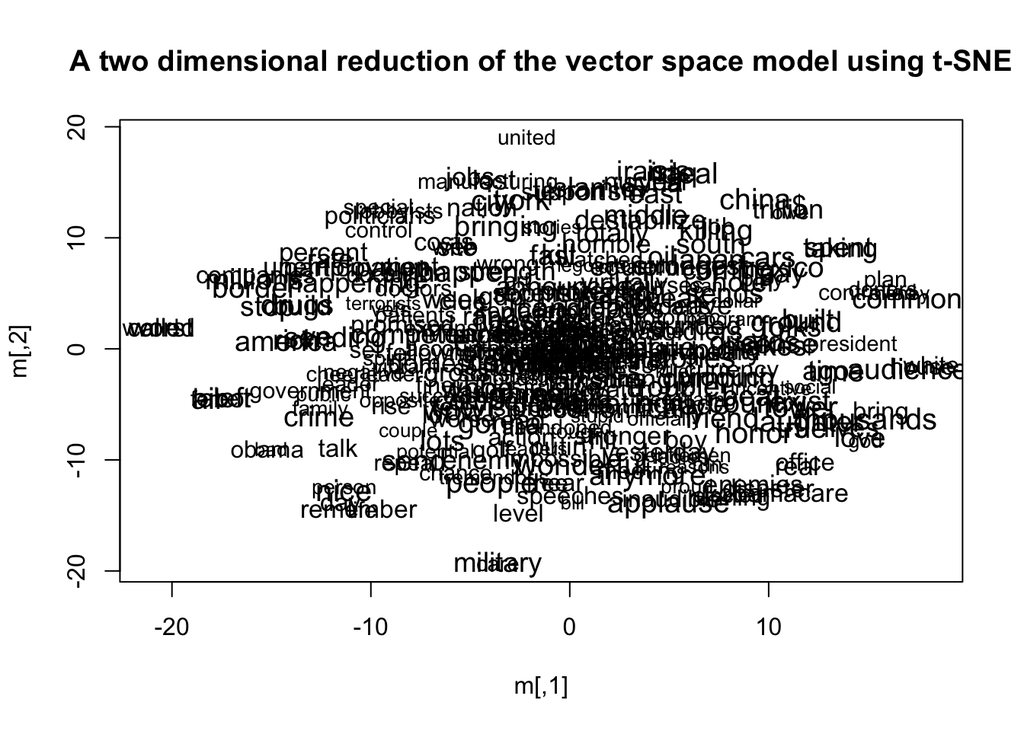

```r
# 畫出wordVectors提供的預設圖
set.seed(5691)
plot_1 <- plot(trump_w2v, perplexity = 30)
```

```r
# 預設是只畫前300個詞。
# ?wordVectors::`plot,VectorSpaceModel-method`

# 若不想使用預設的方式，也可以自行算出降維的座標後再畫出
tsne <- Rtsne(
              # 只取前150個字來畫
              trump_svd$u[1:150, ],
              # 複雜度越小，分群會越明顯，但可能會降低詞義的一致性
              perplexity = 5,
              check_duplicates = FALSE)
names(tsne) # 我們需要的是Y裡面提供的座標軸
```

```
##  [1] "N"                   "Y"                   "costs"
##  [4] "itercosts"           "origD"               "perplexity"
##  [7] "theta"               "max_iter"            "stop_lying_iter"
## [10] "mom_switch_iter"     "momentum"            "final_momentum"
## [13] "eta"                 "exaggeration_factor"
```

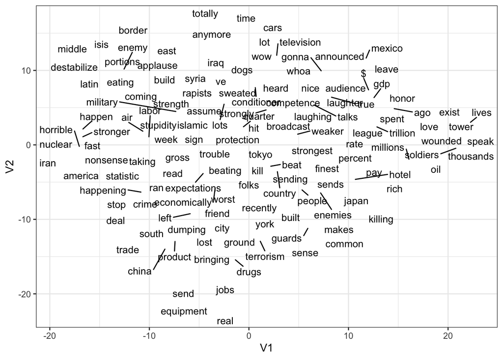

```r
# 將座標資料取出，改用ggplot2畫。
library(ggrepel) ## install.packages("ggrepel")
tsne_plot <- tsne$Y %>%
  as_tibble() %>%
  mutate(word = rownames(trump_svd$u)[1:150]) %>%
  ggplot(aes(x = V1, y = V2)) +
  # geom_text(aes(label = word), size = 3.5) +
  geom_text_repel(aes(label = word), size = 3.5) +
  theme_bw()
tsne_plot
```

```
## Attempting to use T-SNE to plot the vector representation
```

```
## Cancel if this is taking too long
```

```
## Or run 'install.packages' tsne if you don't have it.
```

```
## sigma summary: Min. : 0.247549328937347 |1st Qu. : 0.567284940736271 |Median : 0.64946219965958 |Mean : 0.628250856279063 |3rd Qu. : 0.714803107464982 |Max. : 0.963322039447186 |
```

```
## Epoch: Iteration #100 error is: 15.7735136459446
```

```
## Epoch: Iteration #200 error is: 0.994454777045886
```

```
## Epoch: Iteration #300 error is: 0.830848604457503
```

```
## Epoch: Iteration #400 error is: 0.749188594912791
```

```
## Epoch: Iteration #500 error is: 0.68939565858325
```

```
## Epoch: Iteration #600 error is: 0.66742740818114
```

```
## Epoch: Iteration #700 error is: 0.662906988496759
```

```
## Epoch: Iteration #800 error is: 0.658782958381558
```

```
## Epoch: Iteration #900 error is: 0.648174559890995
```

```
## Epoch: Iteration #1000 error is: 0.641667166564633
```

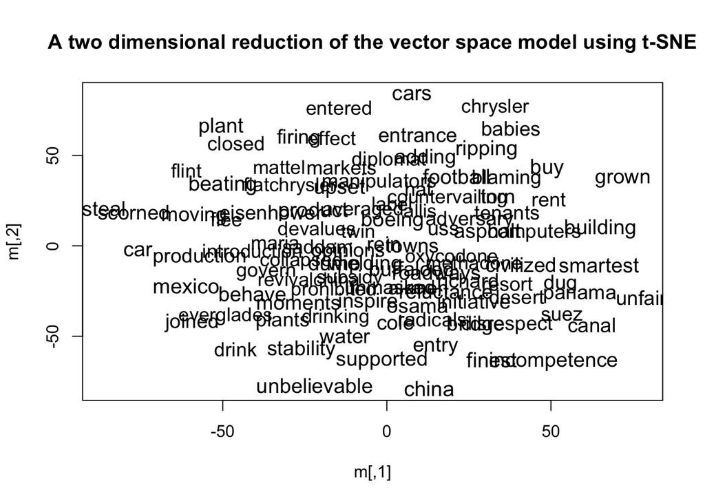

```r
# 只取出部分詞語來畫圖
tariff <- trump_w2v %>%
  closest_to(.[[c("tariff","china","mexico")]], 100)

tariff_res <- trump_w2v[[tariff$word, average = FALSE]]
plot(tariff_res, method = "tsne")
```

看看畫出來的圖，越接近的詞代表在**所使用的語料中詞義越接近**，是否符合你的預期呢？  
想知道更多`wordVectors`的功能，可以參考套件作者寫的 [簡要教學](https://github.com/bmschmidt/wordVectors/blob/master/vignettes/introduction.Rmd)

# 練習1

試試看填入你有興趣的詞彙，找出詞義最相近的詞。

```r
trump_w2v %>% wordVectors::closest_to(vector = "", n = 15)
```

## 3. 中文資料

接下來我們用中文資料試試看。

```r
news <- readr::read_rds("data/news_df.rds") %>%
  select(news_id, content, source)
glimpse(news)
```

```
## Rows: 469
## Columns: 3
## $ news_id <dbl> 1, 2, 3, 4, 5, 6, 7, 8, 9, 10, 11, 12, 13, 14, 15, 16, 17, 18,…
## $ content <chr> "監察院調查發現，行政院對老農年金制度改革不力，致農委會、內政…
## $ source  <chr> "udn", "udn", "udn", "udn", "udn", "udn", "udn", "udn", "udn",…
```

雖然中文資料與英文資料不同，但還是有斷詞與基本的資料清理必須要先做。

```r
seg_engine <- worker(bylines = TRUE)

zh_stopwords <- stopwords::stopwords(language = "zh", source = "misc")

news_token <- news %>%
  # 斷詞
  mutate(token = segment(content, seg_engine)) %>%
  select(-content) %>%
  # 這步比較特別，因為要維持一個vector包含多個中文詞，並且每個中文詞都以一個空白隔開的格式，所以這樣處理。
  mutate(token = map_chr(token, ~paste(.x, collapse = " "))) %>%
  # 將中文停用詞移除，因為不是每個詞都存在一個觀察值內，所以不是用anti_join的方式移除。
  mutate(token = tm::removeWords(token, zh_stopwords)) %>%
  select(news_id, token, source)
```

基本的資料清理完成，接下來的流程完全與英文部分的方式一樣。不過需要考慮中文與英文使用上的不同，在形成`fcm`時是否需要調整參數，如計算脈絡詞的window size是否要增大。

```r
news_toks <- quanteda::corpus(news_token, docid_field = "news_id",
                       text_field = "token") %>%
  tokens() %>%
  # 只留下長度大於2的詞彙
  tokens_select(min_nchar = 2,
                # 因為很多詞會因為長度小於2而被刪除，位置會因此而被縮小，所以設定padding，讓被移除字的位置留空。
                padding = TRUE)

# 實際做出詞共現矩陣
news_fcm <- quanteda::fcm(
  # x可以是    tokens or dfm object
  x = news_toks,
  context = "window",
  count = "weighted",
  window = 6L,
  ordered = FALSE,
  span_sentence = TRUE)
```

```r
# 轉換成矩陣格式（是否一定要執行？）
news_mat <- as.matrix(news_fcm)

# 奇異值分解（singular value decomposition, SVD）
# 降維
tictoc::tic()
news_svd <- irlba(news_mat,
                   # 要轉換成多少維度的向量空間（欄位）
                   nv = 200, maxit = 1e3)
tictoc::toc()
```

```
## 234.885 sec elapsed
```

```r
beepr::beep(2) # 增加提醒聲音，表示工作完成了

# 看看trump_svd裡面有哪些資訊
names(news_svd)
```

```
## [1] "d"     "u"     "v"     "iter"  "mprod"
```

```r
# d 代表奇異值（singular value），v 代表奇異值向量。我們需要的是重組過後的奇異值向量。

# 檢視矩陣的維度（列、欄數）
dim(news_svd$u)
```

```
## [1] 12652   200
```

```r
# 因為svd矩陣是沒有rownames，把原本的rownames加回去，方便之後計算相似度的語法
rownames(news_svd$u) <- rownames(news_mat)

# 轉換為wordVectors的object，就可以直接用比較簡要的function來算相似性
news_w2v <- wordVectors::as.VectorSpaceModel(news_svd$u)
```

我們同樣可以使用向量的概念加以運算，算出在現有語料中，哪些詞語在現有200維空間中的意思最接近。

```r
# 找語義（semantics）最接近的詞
news_w2v %>% closest_to("公務人員", 15)
```

```
##        word similarity to "公務人員"
## 1  公務人員                1.0000000
## 2      烘乾                0.7867151
## 3      傻子                0.7048437
## 4      血親                0.6116430
## 5      會員                0.5871314
## 6      以內                0.5870592
## 7      白花                0.5837033
## 8  堅守崗位                0.5732605
## 9    過日子                0.5553285
## 10     自備                0.5502931
## 11     用詞                0.5363650
## 12     公假                0.4681950
## 13     較差                0.4204858
## 14     進貨                0.4180371
## 15     咳嗽                0.4119467
```

```r
# 如同向量一樣，也可以做加減
news_w2v %>% closest_to(~ "公務人員" - "考試", 15)
```

```
##        word similarity to "公務人員" - "考試"
## 1  公務人員                         0.6903105
## 2      烘乾                         0.5983860
## 3      傻子                         0.5274789
## 4      血親                         0.4551088
## 5      白花                         0.4509365
## 6  堅守崗位                         0.4455138
## 7      會員                         0.4418279
## 8      自備                         0.4409296
## 9      以內                         0.4382099
## 10   過日子                         0.4168665
## 11     用詞                         0.3914063
## 12     公假                         0.3669801
## 13     較差                         0.3243847
## 14     進貨                         0.3148785
## 15     咳嗽                         0.3136712
```

```r
news_w2v %>% closest_to(~ "公務人員" + "考試", 15)
```

```
##        word similarity to "公務人員" + "考試"
## 1      考試                         0.7232057
## 2  公務人員                         0.7003250
## 3      烘乾                         0.4963886
## 4      傻子                         0.4532498
## 5      血親                         0.3959041
## 6      以內                         0.3786168
## 7      會員                         0.3751470
## 8      白花                         0.3614249
## 9      名列                         0.3594949
## 10   過日子                         0.3558418
## 11     登場                         0.3552730
## 12     用詞                         0.3547651
## 13 堅守崗位                         0.3523493
## 14     憂心                         0.3382221
## 15     自備                         0.3251452
```

```r
news_w2v %>% closest_to(~ "貪污", 15)
```

```
##        word similarity to "貪污"
## 1      貪污            1.0000000
## 2      政策            0.6907812
## 3      試算            0.6872642
## 4  明目張膽            0.6824185
## 5    事實上            0.6676888
## 6      流失            0.6606077
## 7      錯誤            0.6523210
## 8      各種            0.6202856
## 9      不致            0.6166710
## 10     辯護            0.5903305
## 11   鐵飯碗            0.5680009
## 12     鐵票            0.5586824
## 13     施政            0.5415337
## 14     魚翅            0.5261629
## 15     信用            0.4858928
```

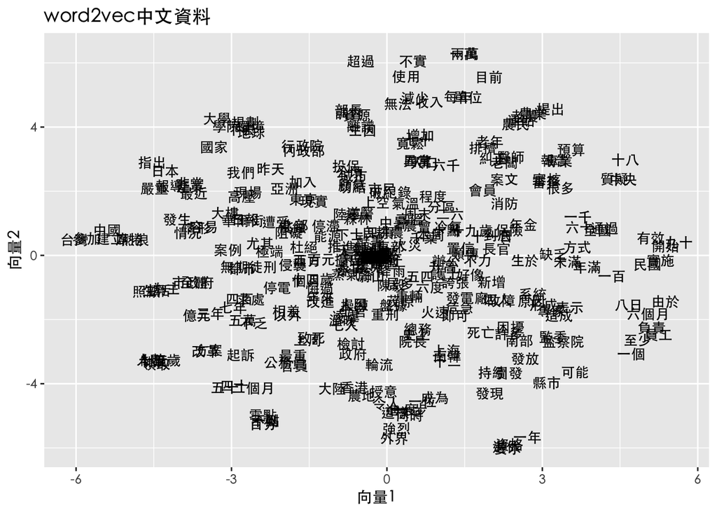

```r
# 中文資料一樣可以像英文資料的程式碼自行製作t-SNE的座標軸出來，再用ggplot2的方式畫出。
tsne_news <- Rtsne(
              # 只取前300個字來畫
              news_svd$u[1:300, ],
              # 複雜度越小，分群會越明顯，但可能會降低詞義的一致性
              perplexity = 40,
              check_duplicates = FALSE)

(tsne_plot_news <- tsne_news$Y %>%
  as_tibble() %>%
  mutate(word = rownames(news_svd$u)[1:300]) %>%
  ggplot(aes(x = V1, y = V2)) +
  geom_text(aes(label = word), size = 3.5, family="STHeitiTC-Medium")+
  theme(text = element_text(family = "STHeitiTC-Medium"))+
  labs(x="向量1", y = "向量2", title="word2vec中文資料")
)
```

也許目前看來詞嵌入的模型結果並不是讓人十分滿意，但請記得這個方法適用的條件：巨量語料（至少100萬以上tokens）。因為我們現在使用的語料相對都比較小，並且也沒有花太多工夫好好清理資料，所以效果不會太好是可以預見的。詞嵌入算是繼續鑽研文字探勘的基本功夫，也是邁向進階分析方法不可或缺的觀念，請有心繼續鑽研的同學務必理解詞嵌入的概念。

## bonus 向量空間教學系列影片

[vector](https://www.youtube.com/watch?v=fNk_zzaMoSs&list=PLZHQObOWTQDPD3MizzM2xVFitgF8hE_ab&index=1)的教學影片（有中文字幕），**非常推薦觀看**，幫助你更瞭解在多維空間下的向量意涵。

[其他教學資源](https://cbail.github.io/textasdata/word2vec/rmarkdown/word2vec.html)

## bonus 其他套件：text2vec

[text2vec](http://text2vec.org/)也是很多人會使用的詞嵌入套件，但因為非使用tidyverse邏輯，且操作方式比較特別，所以沒多做介紹。若處理的是英文資料，此套件有詳細的說明文件，照著操作應該還是可以做出成果。

[conText](https://cran.r-project.org/web/packages/conText/vignettes/quickstart.html)近期推出的新套件，特點在於可以結合pre-trained的資料，做embedding regression。